## The Most Harmful Weather

### Synopsis

Research funding to predict weather events and prepare for weather events can be focused on the highest impact weather types. This brief study identifies the type of weather events that have caused the most harm in terms of *public health* and *economic consequences*.

The weather events in recent history that are most harmful to public health are:  
* Tornados  
* Excessive Heat

The weather events in recent history with the most harmful economic consequesnces are:  
* Tornados  
* Flash Floods

Predicting and preparing for these event types will ensure that we are focusing on the most harmful weather.

### Sources

**Data Sources**

The data for this analysis originates from the U.S. National Oceanic and Atmospheric Administration’s (NOAA). It contains weather event data starting in 1950 and ending in 2011.

The following code loads the data file into R’s working directory from the Coursera website as part of the [Reproducible Research](https://www.coursera.org/course/repdata) course from John Hopkins University. This data is loaded into the working environment as a data frame called ‘data’.

```r
url <- "https://d396qusza40orc.cloudfront.net/repdata%2Fdata%2FStormData.csv.bz2"
download.file(url, destfile = "repdata_data_StormData.csv.bz2", method = "curl")
data <- read.csv("repdata_data_StormData.csv.bz2")
```

**Analysis Tools**

The primary tool for this analysis is RStudio which builds on the statistical scripting language R and it’s many packages. The additional packages required for this analysis are ‘dplyr’ for data processing and ‘ggplot2’ for plotting.

```r
require(dplyr)
```

```r
require(ggplot2)
```

The results have been published using the publish feature in RStudio so it can be viewed by the general public on the [RPubs website](http://rpubs.com/rnplett/weather-harm).

### Data Processing

**Analysis Methodology**

The analysis methodology is shaped by the question of which weather events are most harmful with respect to *population health* and *economic consequences*.

The available data fields were reviewd with respect to population health and econonmic consequences and the following fields were identified as the most representative indicators:  
* Population Health -> FATALITIES field  
* Econonmic Consequences -> the sum of PROPDMG and CROPDMG fields

Other fields that could be used as indicators in further study include:  
* Population Health: INJURIES

Note: Fatalities and Injuries are both health related but are very different metrics and should be analyzed seperately. Both economic related fields are in dollars so they can be viewed as an aggregate.

**Code**

The first section of analysis code works with the data frame as a whole. Here the code calculates the number of years in the data so an acurate average annual amount can be calculated for the displayed variables. Average annual numbers are more meaningful to the reader than a large sum.

```r
Years <- as.character(data$BGN_DATE)
First_Year = min(as.integer(gsub("^.*/(....) .*$","\\1", Years)))
Last_Year = max(as.integer(gsub("^.*/(....) .*$","\\1", Years)))
YearsInStudy <- Last_Year - First_Year + 1
```

The second section of code prepares the plotting data using the dplyr package. Here are a few notes on what is being done:  
* data is grouped by the weather event type  
* for each weather event type the code calculates the average annual fatalities and damage cost  
* since we are only interested in the most harmful weather types we only pull the first 25 weather events and only label the first 3 for plotting.  
* we use the fatalities data for choosing the most harmful events based on the assumption that events causing the most financial damaging events are not without significant fatalities. This assumption was not tested in this analysis.

```r
PlotData <- data %>%
        group_by(EVTYPE) %>%
        select(FATALITIES,PROPDMG,CROPDMG) %>%
        summarise(
                Ann_FATALITIES = sum(FATALITIES, na.rm = TRUE)/YearsInStudy,
                Ann_DAMAGE = sum(PROPDMG,CROPDMG, na.rm = TRUE)/YearsInStudy
                ) %>%
        arrange(desc(Ann_FATALITIES)) %>%
        head(n = 25) %>%
        mutate(Label = c(as.character(EVTYPE[1:3]),rep(NA,22)))
```

The next section of code plots the harm data prepared in the previous section. It displays economic damage vs fatalities for the most harmful weather event types.

Note: The economic damage does not indicate units of measure. The unit of measure is not required to communicate relative impact for various weather events. The original data was clear that the unit was in dollars but didn’t indicate thousands or millions of dollars so to avoid confusion the numbers have been hidden.

```r
HarmPlot <- ggplot(PlotData,aes(Ann_FATALITIES, Ann_DAMAGE)) +
        labs(title = "The Most Harmful Weather Events \n (Average Annual Harm)",
             x = "Harm to Public Health \n (Fatalities)",
             y = "Economic Consequences \n (Property and Crop Damage)") +
        xlim(0,100) +
        geom_point() +
        geom_text(aes(x = Ann_FATALITIES,
                      y = Ann_DAMAGE + 2000,
                      label=Label),
                  size=3) +
        theme_bw() +
        theme(axis.text.y = element_blank(),
              axis.ticks.y = element_blank())
```

### Results

**The Most Harmful Weather Events**

The most harmful weather events can be plotted as follows:

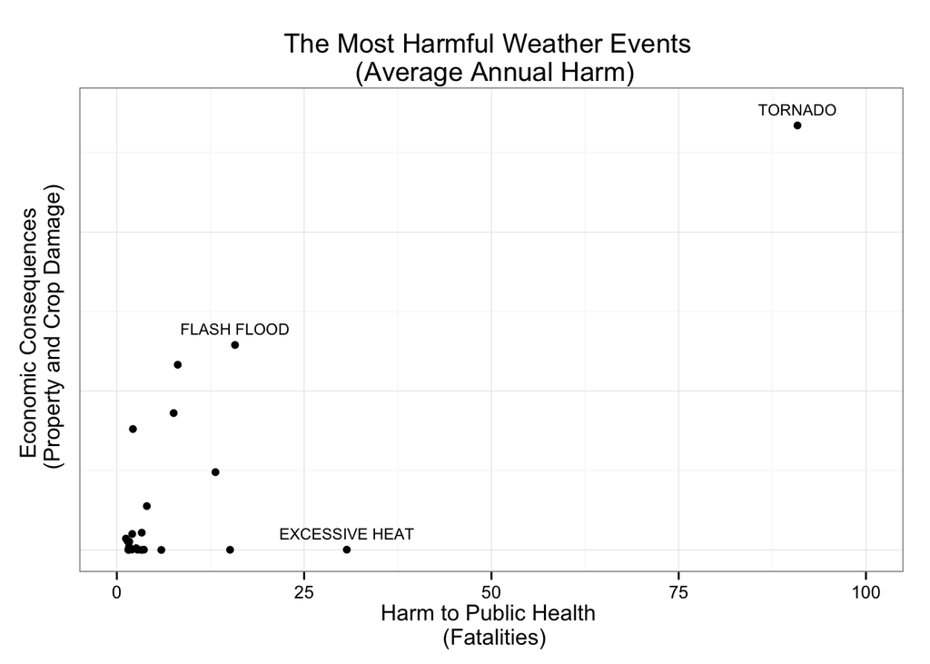

```r
HarmPlot
```

This plot shows the harm of weather events as dots in terms of public health (Fatalities) along the horizontal axis and in terms of economic consequences (Property and Crop Damage) along the vertical axis. Weather events that appear furthest to the right have the most public health impact and the events that appear closest to the top have the biggest econonmic consequences.

The weather events in recent history that are most harmful to public health are:  
* Tornados  
* Excessive Heat

The weather events in recent history with the most harmful economic consequesnces are:  
* Tornados  
* Flash Floods

Predicting and preparing for these types of events will ensure that we are focusing on the most harmful weather.